# Supplementary 5: Spatial Error Linear Model with Forest as predictor

Camille M. Crapart

27 06 2022

**[Back to main menu](https://camilmc.github.io/TOC_trend_1995/)**

```r
library(dplyr)
library(tibble)

library(DBI)
library(sf)
library(gimms)

library(ncdf4)
library(rgdal)

library(stringr)
library(ggplot2)
library(RColorBrewer)
library(cowplot)
library(png)
library(colorspace)

library(spdep)
library(spatialreg)

library(grid)
library(kableExtra)
library(reshape2)

source("f_plotspatial.R")
fennoscandia <- readRDS("fennoscandia.rds")

memory.limit(size = 160000)
```

```
## [1] 160000
```

```r
library(captioner)
fig_nums <- captioner()
table_nums <- captioner(prefix = "Table")
```

```r
compute.effect.size <- function(df.coef){

df.es <- df.coef[,1:3]
n <- length(df.es$Parameter)
m <- df.es$Parameter


for(i in 1:n){
  if(grepl("log",m[i])==T){
    df.es[i,2] <- 1.01^(df.coef[i,2])
    df.es[i,3] <- 1.01^(df.coef[i,2])*log(1.01)*df.coef[i,3]
  }else if(m[i] %in% c("NDVI","Bog","Arable","Forest","Temp")){
    df.es[i,2] <- exp(df.coef[i,2]*0.01)
    df.es[i,3] <- 0.01*df.coef[i,2]*df.coef[i,3]
  }else if(m[i] %in% c("TNdep","TSdep")){
    df.es[i,2] <- exp(df.coef[i,2]*25)
    df.es[i,3] <- 25*exp(df.coef[i,2]*25)*df.coef[i,3]
  } else {
    df.es[i,2] <- exp(df.coef) # effect size for temperature???
  }
}

df.es$Percent <- 100*(df.es$Estimate-1)

return(df.es)

}

# other es
eslog <- 1.01
es <- 0.01
```

# 1 Introduction

Forest management is an essential tool in achieving the commitments in the Fennoscandian climate policies (Sundnes et al. 2020). In line with the Declaration on Forest and Land Use signed on November 2021(UN Climate Change Conference UK 2021), the Fennoscandian governments consider forest as a leverage for offsetting their carbon emissions and reaching their zero-emission goals (Nordic Council of Ministers 2021) Norway, Sweden and Finland (collectively labelled Fennoscandia) are not subject to deforestation with 43.5, 65.5 and 70.9% (OECD 2020), respectively, of their territories covered with forest.These boreal forests hold large belowground and peatland pools of organic carbon. During the last century, the Fennoscandian forest volume has increased some 25% (ref). Most of this is a result from massive forest planting campaigns in the 50ies and 60ies, but forest growth has also benefited from a milder climate, with longer growing seasons, as well as the accumulation of reactive nitrogen from long-range transported air pollution and potentially also increased atmospheric concentrations of CO2. This increased forest volume also implies a strong C-sequestration, and current policies in the Nordics promote the intensification of the forest industry. In Norway, the ministry of Environment (Miljødirektoratet) subsidies densification of the planted areas and the afforestation of new so-called Climate forests (Miljødirektoratet 2013). In Fennoscandia as a whole, timber industry is a major economical resource (Royal Swedish Academy of Agriculture and Forestry 2015). Forestry products account for 23% of the Swedish total exports and the standing biomass doubled over the last 100 years (Näringsdepartementet 2018). Formas, the Swedish government research council for sustainable development, promotes bioeconomy as a major climate mitigation tool (Formas 2012). Similarly, in Finland the national subsidy schemes aim at intensifying the forestry sector. A fifth of the Finnish export of goods come from the wood industry. (Ministry of Agriculture and Forestry 2014). The Finnish forest legislation was renewed in the 2010s to improve its competitiveness while conserving its goals in terms of sustainability.

The planned intensification of forest management and afforestation has, on the other hand, raised concern regarding the water quality (Norsk Vann 2019). In Norway, 90% of the raw water used for drinking water comes from surface waters (Energifakta Norge n.d.). Browning has potential impact on the required raw water treatment to ensure potability of water (Eikebrokk, Vogt, and Liltved 2004). In addition, browning impact lakes by reducing light absorbance, and thus reducing primary production (Karlsson 2007), while at the same time increasing the CO2 and CH4 emissions from the lakes, especially in small lakes [Yang et al. (2015); Parra et al. ms ; Wit et al. (2018)], further increasing the net heterotrophy that prevails in boreal lakes (Tranvik et al. 2009). Reduced primary production propagate up the trophic ladder and also affect fish, both via reduced productivity, but also by affecting visual feeding in fish (Finstad et al. 2014) and thermal regimes (Karlsson et al. 2009; Craig et al. 2017). The current browning of freshwater lakes and rivers also entails the darkening of coastal waters, delaying phytoplankton spring blooms and decreasing coastal primary production (Opdal, Lindemann, and Aksnes 2019). Understanding the governing factors for TOC concentration under local anthropogenic and regional climatic stresses is therefore essential to forecast its potential detrimental effects to the water quality and ecosystem services.

NDVI and Forest cover are both proxy for the biomass amount on the catchment. However, they are poorly correlated (0.62) and are not expected to have exactly the same effect on TOC concentration in time. To investigate the effect of an increase of forest cover in Norway, Sweden and Finland, in line with the forest policies in these three countries, an alternative model was fitted using Forest (instead of NDVI), Bog and Runoff as predictors based on the Northern Lake Survey (1995). Then, the model was tested with the 2019 survey and the forecast made for 2100, when planted trees will have reached maturity.

# 2 Spatial error model with Forest as predictor

A Spatial error model was fitted on the Fennoscandia dataset with Forest, logRunoff and Bog as predictors.

```r
k.neigh.w <- readRDS("k.neigh.w.Rdata")
fm <- logTOC ~ Forest+logRunoff+Bog
sem.forest.fen <- errorsarlm(fm, data = fennoscandia,k.neigh.w)

saveRDS(sem.forest.fen, "sem.forest.fen.Rdata")
```

```r
k.neigh.w <- readRDS("k.neigh.w.Rdata")

sem.forest.fen <- readRDS("sem.forest.fen.Rdata")
sem.forest.norge <- readRDS("sem.forest.norge.Rdata")

sem.coef.forest <- sem.forest.fen$coefficients[-1] %>% as.data.frame() %>%
              setNames("Estimate")
sem.coef.forest <- sem.coef.forest %>% rownames_to_column(var = "Parameter")
sem.coef.forest$std.error <- sem.forest.fen$rest.se[-1]
saveRDS(sem.coef.forest,"sem.coef.forest.rds")

sem.effectsize.forest <- compute.effect.size(sem.coef.forest)
saveRDS(sem.effectsize.forest,"sem.effectsize.forest.rds")

n <- length(sem.coef.forest$Parameter)

sem.AIC <- 2*(n-1)-2*sem.forest.fen$LL
moran.I.res.sem <- moran.test(sem.forest.fen$residuals, k.neigh.w, alternative = "two.sided")

summary.table.sem.forest <- cbind(dplyr::select(sem.coef.forest,Parameter),sem.coef.forest[,2:3],sem.effectsize.forest[,2:4]) %>%
                rbind(c("AIC",sem.AIC,"","","","")) %>%
                rbind(c("Moran'I res", moran.I.res.sem$estimate[[1]], "","","",""))
summary.table.sem.forest[,-1] <- apply(summary.table.sem.forest[,-1],2,as.numeric)
saveRDS(summary.table.sem.forest,"summary.table.sem.forest.rds")
```

```r
norge.kmat <- readRDS("norge.kmat.Rdata")

fm <- logTOC ~ Forest+logRunoff+Bog

sem.forest.norge <- errorsarlm(fm, data = norge,norge.kmat)

saveRDS(sem.forest.norge, "sem.forest.norge.rds")
```

```r
norge.kmat <- readRDS("norge.kmat.Rdata")
sem.forest.norge <- readRDS("sem.forest.norge.rds")

sem.coef.norge.forest <- sem.forest.norge$coefficients[-1] %>% as.data.frame() %>%
              setNames("Estimate")
sem.coef.norge.forest <- sem.coef.norge.forest %>% rownames_to_column(var = "Parameter")
sem.coef.norge.forest$std.error <- sem.forest.norge$rest.se[-1]
saveRDS(sem.coef.norge.forest, "sem.coef.norge.forest.rds")

sem.effectsize.forest.norge <- compute.effect.size(sem.coef.norge.forest)
saveRDS(sem.effectsize.forest.norge, "sem.effectsize.forest.norge.rds")

n <- length(sem.coef.norge.forest$Parameter)
sem.AIC.norge <- 2*(n-1)-2*sem.forest.norge$LL
moran.I.res.sem.norge <- moran.test(sem.forest.norge$residuals, norge.kmat, alternative = "two.sided")

summary.table.sem.forest.norge <- cbind(dplyr::select(sem.coef.norge.forest,Parameter),sem.coef.norge.forest[,2:3],sem.effectsize.forest.norge[,2:4]) %>%
                rbind(c("AIC",sem.AIC.norge,"","","","")) %>%
                rbind(c("Moran'I res", moran.I.res.sem.norge$estimate[[1]], "","","",""))
summary.table.sem.forest.norge[,-1] <- apply(summary.table.sem.forest.norge[,-1],2,as.numeric)
saveRDS(summary.table.sem.forest.norge, "summary.table.sem.forest.norge.rds")
```

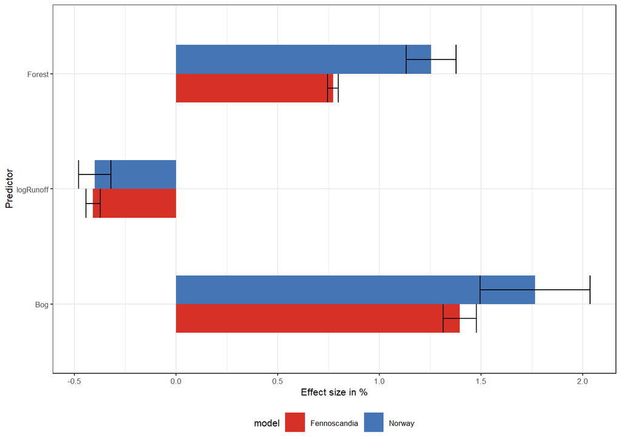

```r
sem.effectsize.forest <- readRDS("sem.effectsize.forest.rds")
sem.effectsize.forest.norge <- readRDS("sem.effectsize.forest.norge.rds")

n <- c(names(sem.effectsize.forest),"model")
m <- cbind.data.frame(sem.effectsize.forest,model = "Fennoscandia") %>% setNames(n)
o <- cbind.data.frame(sem.effectsize.forest.norge,model = "Norway")

h.df <- rbind(m,o)
h.df$Parameter <- factor(h.df$Parameter, levels = c("Bog","logRunoff","Forest"))

effectsize.plot <- ggplot(h.df, aes(group = model))+
  geom_col(aes(x=Percent,y=Parameter, fill = model), position = "dodge", width = 0.5)+
  scale_fill_manual(values = c("#d73027","#4575b4"))+
  geom_errorbar(aes(y=Parameter,xmin = Percent-(100*std.error),xmax=Percent+(100*std.error)), position = "dodge", width = 0.5)+
  labs(x = "Effect size in %", y = "Predictor")+
  theme_bw(base_size = 8)+theme(legend.position = "bottom")
ggsave(plot = effectsize.plot,filename = "effectsize.forest.plot.png", dpi = "retina", width = 7, height = 8, units = "cm")
print(effectsize.plot)
```

*Figure 1: Effect size for SELM model with forest as predictor instead of NDVI*

```r
summary.table.sem.forest <- readRDS("summary.table.sem.forest.rds")

n <- 3

knitr::kable(summary.table.sem.forest,digits = 4) %>%
  add_header_above(c("Model"=1, "SELM" = 2, "Effect size" = 3),italic = T) %>%
  kable_styling(bootstrap_options = "bordered") %>%
  column_spec(column = 6, bold = T) %>%
  group_rows(group_label = "Model Evaluation", start_row = n+1,end_row=n+1)
```

| Model Parameter | SELM Estimate | SELM std.error | Effect size Estimate | Effect size std.error | Effect size Percent |
| --- | --- | --- | --- | --- | --- |
| Forest | 0.7690 | 0.0338 | 1.0077 | 3e-04 | 0.7720 |
| logRunoff | -0.4113 | 0.0351 | 0.9959 | 3e-04 | -0.4085 |
| Bog | 1.3853 | 0.0597 | 1.0139 | 8e-04 | 1.3949 |
| **Model Evaluation** |  |  |  |  |  |
| AIC | 6452.4920 |  |  |  |  |
| Moran’I res | 0.0201 |  |  |  |  |

```r
summary.table.sem.forest.norge <- readRDS("summary.table.sem.forest.norge.rds")

n <- 3

knitr::kable(summary.table.sem.forest.norge,digits = 4) %>%
  add_header_above(c("Model"=1, "SELM" = 2, "Effect size" = 3),italic = T) %>%
  kable_styling(bootstrap_options = "bordered") %>%
  column_spec(column = 6, bold = T) %>%
  group_rows(group_label = "Model Evaluation", start_row = n+1,end_row=n+1)
```

| Model Parameter | SELM Estimate | SELM std.error | Effect size Estimate | Effect size std.error | Effect size Percent |
| --- | --- | --- | --- | --- | --- |
| Forest | 1.2469 | 0.0986 | 1.0125 | 0.0012 | 1.2547 |
| logRunoff | -0.4040 | 0.0804 | 0.9960 | 0.0008 | -0.4011 |
| Bog | 1.7498 | 0.1552 | 1.0177 | 0.0027 | 1.7652 |
| **Model Evaluation** |  |  |  |  |  |
| AIC | 1560.6358 |  |  |  |  |
| Moran’I res | 0.0250 |  |  |  |  |

# 3 Fitting NIVA data with forest

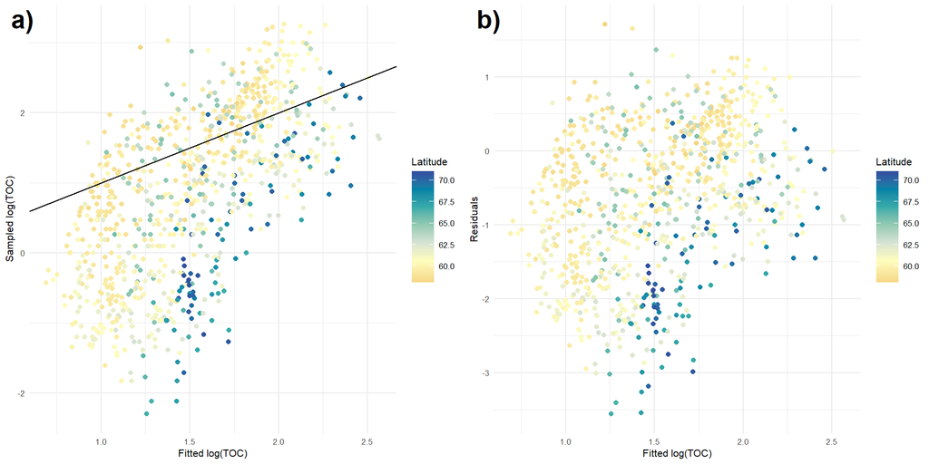

```r
sem.forest.fen <- readRDS("sem.forest.fen.Rdata")
niva_final <- readRDS("NIVA_test/niva_final.rds")
niva.kmat <- readRDS("NIVA_test/niva.kmat.rds")

fm <- logTOC ~ Forest + logRunoff + Bog
sem.forest.fen <- readRDS("sem.forest.fen.Rdata")
niva_fit <- predict(sem.forest.fen, niva_final, niva.kmat)

niva_predict_forest <- cbind(niva_final, niva_fit)
niva_predict_forest$diffTOC <- exp(niva_predict_forest$fit) - niva_predict_forest$toc_2019
niva_predict_forest$diffLogTOC <- log(niva_predict_forest$toc_2019) - niva_predict_forest$fit
saveRDS(niva_predict_forest,"NIVA_test/niva_predict_forest.rds")

g1 <- ggplot(niva_predict_forest) + geom_point(aes(y = log(toc_2019), x = fit, col = latitud))+
  scale_color_continuous_divergingx(palette = "RdYlBu", name = "Latitude", mid = median(niva_predict_forest$latitud))+
  geom_abline(slope = 1, intercept = 0, col = "black")+
  labs(y = "Sampled log(TOC)", x = "Fitted log(TOC)")+ theme_minimal(base_size = 8)

g2 <- ggplot(niva_predict_forest) + geom_point(aes(x = fit, y = log(toc_2019)-fit, col = latitud)) + labs(y = "Residuals", x = "Fitted log(TOC)")+
  scale_color_continuous_divergingx(palette = "RdYlBu", name = "Latitude", mid = median(niva_predict_forest$latitud))+
  theme_minimal(base_size = 8)

plot_grid(g1,g2,nrow = 1, ncol = 2, labels = c("a)","b)"), label_size = 20)
```

*Figure 3: Fitted vs observed log(TOC) concentration on the 2019-survey data based on the SELM model with Forest, Bogs, and log Runoff as predictors*

```r
niva_predict_forest <- readRDS("NIVA_test/niva_predict_forest.rds")
nor <- st_read("Country_shapefile/norway.shp") %>% st_transform(st_crs(wr.sf.95))
lims.toc <- c(min(c(niva_predict_forest$toc_2019, exp(niva_predict_forest$fit))), max((c(niva_predict_forest$toc_2019, exp(niva_predict_forest$fit)))))

diff.niva.forest <- ggplot() + geom_sf(data = nor, fill = "white", col = "lightgray") +
  geom_sf(data = niva_predict_forest, aes(fill = diffTOC, col = diffTOC)) +
  scale_color_continuous_divergingx(palette = "RdYlBu", name = "Difference between\nobserved and predicted TOC\nwith Forest, bogs, runoff (mg/L)", aesthetics = c("fill","col"))+
  labs(x = "", y = "")+
  theme_minimal(base_size = 9)+
  theme(legend.position = "bottom")
ggsave(plot = diff.niva.forest, filename = "NIVA_test/diff.niva.forest.png", dpi = "retina", width = 10, height = 12, units = "cm")

fitted.niva.forest <- ggplot() +geom_sf(data = nor, fill = "white", col = "lightgray") +
  geom_sf(data = niva_predict_forest, aes(fill = exp(fit), col = exp(fit))) +
  scale_color_continuous_divergingx(palette = "RdYlBu", aesthetics = c("fill","col"), name = "Fitted TOC (mg/L)", limits = lims.toc)+
  labs(x = "", y = "")+
  theme_minimal(base_size = 9)+
  theme(legend.position = "bottom")

ggsave(plot = fitted.niva.forest, filename =  "NIVA_test/fitted.niva.forest.png",dpi = "retina", width = 10, height = 12, units = "cm")

obs.niva.forest <- ggplot() + geom_sf(data = nor, fill = "white", col = "lightgray") +
  geom_sf(data = niva_predict_forest, aes(fill = toc_2019, col = toc_2019)) +
  scale_color_continuous_divergingx(palette = "RdYlBu", aesthetics = c("fill","col"), name = "Sampled TOC (mg/L)", limits = lims.toc)+
  labs(x = "", y = "")+
  theme_minimal(base_size = 9)+
  theme(legend.position = "bottom")
ggsave(plot = obs.niva.forest, filename = "NIVA_test/obs.niva.forest.png",dpi = "retina", width = 10, height = 12, units = "cm", device = "png")
```

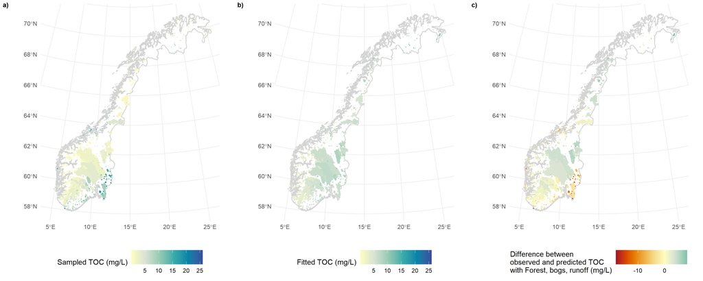

```r
listgrob <- list("NIVA_test/obs.niva.forest.png","NIVA_test/fitted.niva.forest.png","NIVA_test/diff.niva.forest.png") %>% lapply(readPNG) %>% lapply(rasterGrob)
plot_grid(plotlist = listgrob, nrow = 1, ncol = 3, labels= c("a)","b)","c)"), label_size = 20)
```

# 4 Forecast of mean TOC concentration with an increase of forest cover

## 4.1 TOC prediction for 1995 on water regions

```r
sem.forest.fen <- readRDS("sem.forest.fen.Rdata")
wr.sf.95 <- readRDS("WR/wr.sf.95.rds")
fm <- logTOC~Forest+logRunoff+Bog
wr.pred <- predict(sem.forest.fen,wr.sf.95,wr.kmat, pred.type = "TS",legacy.mixed = F, zero.policy = T) %>% as.data.frame()

sem.pred.forest.wr <- cbind(wr.sf.95,wr.pred$fit)
sem.pred.forest.wr$TOC95 <- exp(sem.pred.forest.wr$wr.pred.fit)

saveRDS(sem.pred.forest.wr,"WR/sem.pred.forest.wr.rds")

map.fit.forest <- ggplot()+geom_sf(data = st_as_sf(sem.pred.forest.wr), aes(fill = TOC95, col = TOC95))+
  scale_fill_distiller(type = "seq", palette = 8, aesthetics = c("colour","fill"), direction = 1,
                       name = "Modelled TOC 1995 (mg/L)\n using forest model")+
  theme_minimal(base_size = 6)+
  theme(legend.position = "bottom")
ggsave(plot = map.fit.forest, filename = "WR/wr.toc.forest.png",dpi = "retina", width = 6, height = 8, units = "cm")
```

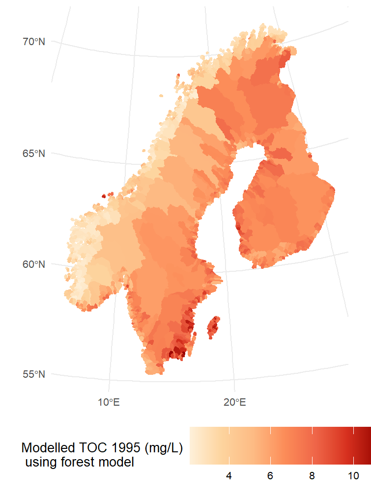

```r
knitr::include_graphics("WR/wr.toc.forest.png")
```

*Figure 5: Fitted mean TOC concentration for the water regions in 1995 data based on the SELM model with Forest, Bogs, and log Runoff as predictors*

## 4.2 Prediction of forest increase in Norway, Sweden and Finland

We assessed the increase in forest cover based on numbers presented in policy papers. In Finland, 26,18 million ha LUKE (n.d.) are covered with forest and 90 000 are expected to be planted by 2065 Lehtonen and Mäkipää (2021). This represents roughly an mean increase of 0,34%. In Sweden, the forest covers 28 million hectares Swedish Forest Agency (2012). The Swedish forest policy includes the afforestation of 190 000 ha Statens Offentliga Utredningar (2020), representing a 0,68% increase. In Norway, the forest covers 8,443 million ha and the plan for afforestation is to increase this cover up to 9,78 million hectare, i.e. 16%.

```r
wr.sf.95 <- readRDS("WR/wr.sf.95.rds")
wr.centroid <- st_centroid(wr.sf.95, of_largest_polygon = T)
sem.pred.forest.wr <- readRDS("WR/sem.pred.forest.wr.rds")

nor <- st_read("Country_shapefile/norway.shp") %>% st_transform(st_crs(wr.centroid))
## Reading layer `norway' from data source
##   `C:\Users\raine\Documents\UiO\Finstad\Country_shapefile\norway.shp'
##   using driver `ESRI Shapefile'
## Simple feature collection with 1 feature and 11 fields
## Geometry type: MULTIPOLYGON
## Dimension:     XY
## Bounding box:  xmin: 3.904688 ymin: 57.95903 xmax: 31.16198 ymax: 71.18125
## Geodetic CRS:  WGS 84
swe <- st_read("Country_shapefile/sweden.shp") %>% st_transform(st_crs(wr.centroid))
## Reading layer `sweden' from data source
##   `C:\Users\raine\Documents\UiO\Finstad\Country_shapefile\sweden.shp'
##   using driver `ESRI Shapefile'
## Simple feature collection with 1 feature and 11 fields
## Geometry type: MULTIPOLYGON
## Dimension:     XY
## Bounding box:  xmin: 10.96139 ymin: 55.33625 xmax: 24.1724 ymax: 69.05904
## Geodetic CRS:  WGS 84
fin <- st_read("Country_shapefile/finland.shp") %>% st_transform(st_crs(wr.centroid))
## Reading layer `finland' from data source
##   `C:\Users\raine\Documents\UiO\Finstad\Country_shapefile\finland.shp'
##   using driver `ESRI Shapefile'
## Simple feature collection with 1 feature and 11 fields
## Geometry type: MULTIPOLYGON
## Dimension:     XY
## Bounding box:  xmin: 20.55121 ymin: 59.72097 xmax: 31.5828 ymax: 70.09145
## Geodetic CRS:  WGS 84

wr.norge <- wr.centroid[nor,]
wr.norge$Nation <- "Norway"
wr.sweden <- wr.centroid[swe,]
wr.sweden$Nation <- "Sweden"
wr.finland <- wr.centroid[fin,]
wr.finland$Nation <- "Finland"

wr.norge$forest_increase <- dbeta(wr.norge$Forest,shape1 = 3, shape2 = 8)/10
i1 <- ggplot(wr.norge)+geom_point(aes(x=Forest,y = forest_increase*100))+labs(x="Current forest proportion", y = "Planned increase (%)",title = "Norway")
mean(wr.norge$forest_increase)
```

```
## [1] 0.1642073
```

```r
wr.sweden$forest_increase <- dbeta(wr.sweden$Forest,shape1 = 3, shape2 = 7)/100
i2 <- ggplot(wr.sweden)+geom_point(aes(x=Forest,y = forest_increase*100))+labs(x="Current forest proportion", y = "Planned increase (%)",title = "Sweden")
mean(wr.sweden$forest_increase)
```

```
## [1] 0.007010394
```

```r
wr.finland$forest_increase <- dbeta(wr.finland$Forest,shape1 = 2, shape2 = 7)/100
i3 <- ggplot(wr.finland)+geom_point(aes(x=Forest,y = forest_increase*100))+labs(x="Current forest proportion", y = "Planned increase (%)",title = "Finland")
mean(wr.finland$forest_increase)
```

```
## [1] 0.003007623
```

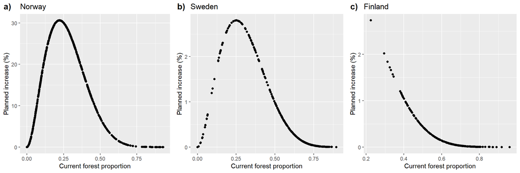

```r
average.increase <- c(mean(wr.norge$forest_increase)*100,mean(wr.sweden$forest_increase)*100,mean(wr.finland$forest_increase)*100)

wr.forest.total <- rbind(wr.norge,wr.sweden,wr.finland)

wr.sf.forest <- wr.sf.95 %>% sp::merge(dplyr::select(st_drop_geometry(wr.forest.total), c("gid","forest_increase","Nation")), by = "gid") %>% sp::merge(dplyr::select(st_drop_geometry(sem.pred.forest.wr), c("gid","wr.pred.fit","TOC95")), by = "gid")

mypal <- brewer.pal(name = "YlGn", n = 9)

plot_grid(i1,i2,i3, nrow = 1, ncol = 3, labels = c("a)","b)","c)"))
```

*Figure 6: Prediction of forest increase with forest policies in a) Norway, b) Sweden, c) Finland*

```r
sem.forest.fen <- readRDS("sem.forest.fen.Rdata")

wr.sf.forest$Forest95 <- wr.sf.forest$Forest
wr.sf.forest$Forest <- wr.sf.forest$Forest95 + wr.sf.forest$forest_increase

fm <- logTOC~Forest+logRunoff+Bog
pred.forest <- predict(sem.forest.fen,wr.sf.forest,wr.kmat, pred.type = "TS",legacy.mixed = F, zero.policy = T) %>% as.data.frame()

wr.forest.pred <- cbind(wr.sf.forest,pred.forest)
wr.forest.pred$TOC <- exp(wr.forest.pred$fit)

saveRDS(wr.forest.pred,"wr.forest.pred.rds")
```

```r
wr.sf.forest <- readRDS("wr.forest.pred.rds")

forest.increase.norge <- ggplot(filter(wr.sf.forest,Nation == "Norway"))+
  geom_sf(aes(fill=forest_increase*100, col = forest_increase*100))+
  scale_fill_distiller(type = "seq", palette = 2, aesthetics = c("fill","colour"), name = "Forest increase (%)", direction = 1)+
  theme_minimal(base_size = 9)+
  theme(legend.position = "bottom")
ggsave(plot = forest.increase.norge, filename = "WR/forest.increase.norge.png",dpi = "retina", width = 10, height = 12, units = "cm")

forest.increase.sweden <- ggplot(filter(wr.sf.forest,Nation == "Sweden"))+
  geom_sf(aes(fill=forest_increase*100, col = forest_increase*100))+
  scale_fill_distiller(type = "seq", palette = 1, aesthetics = c("fill","colour"), name = "Forest increase (%)", direction = 1)+
  theme_minimal(base_size = 9)+
  theme(legend.position = "bottom")
ggsave(plot = forest.increase.sweden, filename = "WR/forest.increase.sweden.png",dpi = "retina", width = 10, height = 12, units = "cm")

forest.increase.finland <- ggplot(filter(wr.sf.forest,Nation == "Finland"))+
  geom_sf(aes(fill=forest_increase*100, col = forest_increase*100))+
  scale_fill_distiller(palette = 4, aesthetics = c("fill","colour"), name = "Forest increase (%)", direction = 1)+
  theme_minimal(base_size = 9)+
  theme(legend.position = "bottom")
ggsave(plot = forest.increase.finland, filename = "WR/forest.increase.finland.png",dpi = "retina", width = 10, height = 12, units = "cm")
```

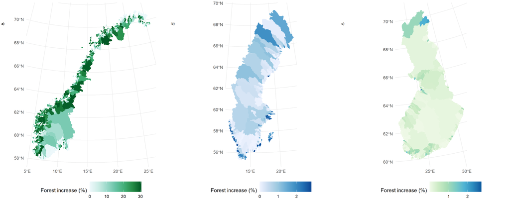

```r
listgrob <- list("WR/forest.increase.norge.png","WR/forest.increase.sweden.png","WR/forest.increase.finland.png" ) %>% lapply(readPNG) %>% lapply(rasterGrob)
plot_grid(plotlist = listgrob, nrow = 1, ncol = 3, labels = c("a)","b)","c)"), vjust = 10)
```

## 4.3 TOC forecast for 2100 with forest increase

The forecast applies for year 2100, when all the planted trees will have reached maturity (Miljødirektoratet 2013).

```r
wr.forest.pred <- readRDS("wr.forest.pred.rds")

wr.forest.long <- wr.forest.pred %>% st_drop_geometry() %>% dplyr::select(c("gid","Nation","Forest95","Forest","forest_increase")) %>% melt(id.vars = c("gid","Nation"), value.name = "Proportion")

levels(wr.forest.long$variable) <- c("Forest (1995)", "Forest (2100)", "Forest increase")
wr.forest.long$Nation <- factor(wr.forest.long$Nation, c("Norway","Sweden","Finland"))
wr.forest.long$Proportion <- wr.forest.long$Proportion * 100
wr.forest.long$Mean <- wr.forest.long

average.increase <- wr.forest.pred %>% st_drop_geometry() %>% group_by(Nation) %>% summarise(mean = mean(forest_increase)*100)

x.lab <- paste("Mean forest increase with beta distribution\nNorway: ", round(average.increase[2,2],2), "%, Sweden:", round(average.increase[3,2],2), "%, Finland: ", round(average.increase[1,2],2), "%",sep = "")

boxplot_compare <- ggplot(wr.forest.long)+
  geom_boxplot(aes(x="", y = Proportion), size = 0.3, outlier.size = 0.3)+
  labs(x = x.lab, y = "%")+
  theme_bw(base_size = 6)+facet_grid(rows = vars(variable), cols = vars(Nation), scales = "free_y")
ggsave(plot = boxplot_compare, filename = "WR/boxplot.forest.png",dpi = "retina", width = 8, height = 10, units = "cm")

map.forest <- ggplot(wr.forest.pred)+geom_sf(aes(fill = Forest95, col = Forest95))+
   scale_fill_distiller(type = "seq", palette = 2, aesthetics = c("colour","fill"), direction = 1, name = "Forest proportion 1995")+
   theme_minimal(base_size = 6)+
   theme(legend.position = "bottom")
ggsave(plot = map.forest, filename = "WR/map.forest.png",dpi = "retina", width = 6, height = 8, units = "cm")

map.toc.forest <- ggplot()+geom_sf(data = wr.forest.pred, aes(fill = TOC, col = TOC))+
  scale_fill_distiller(type = "seq", palette = 8, aesthetics = c("colour","fill"), direction = 1, name = "Modelled TOC with\n an increase of forest cover (mg/L)")+
  theme_minimal(base_size = 6)+
  theme(legend.position = "bottom")

ggsave(plot = map.toc.forest, filename = "WR/map.toc.forest.png",dpi = "retina", width = 6, height = 8, units = "cm")

map.diff.toc.forest <- ggplot()+geom_sf(data = wr.forest.pred, aes(fill = TOC-TOC95, col = TOC-TOC95))+
  scale_fill_gradient2(low="#104E8B",mid="#FFFFE0",high = "#CD3700",midpoint = 0, aesthetics = c("colour","fill"),name = "Difference TOC concentration\n with an increase of forest cover")+
  theme_minimal(base_size = 6)+
  theme(legend.position = "bottom")
ggsave(plot = map.diff.toc.forest, filename = "WR/map.diff.toc.forest.png",dpi = "retina", width = 6, height = 8, units = "cm")
```

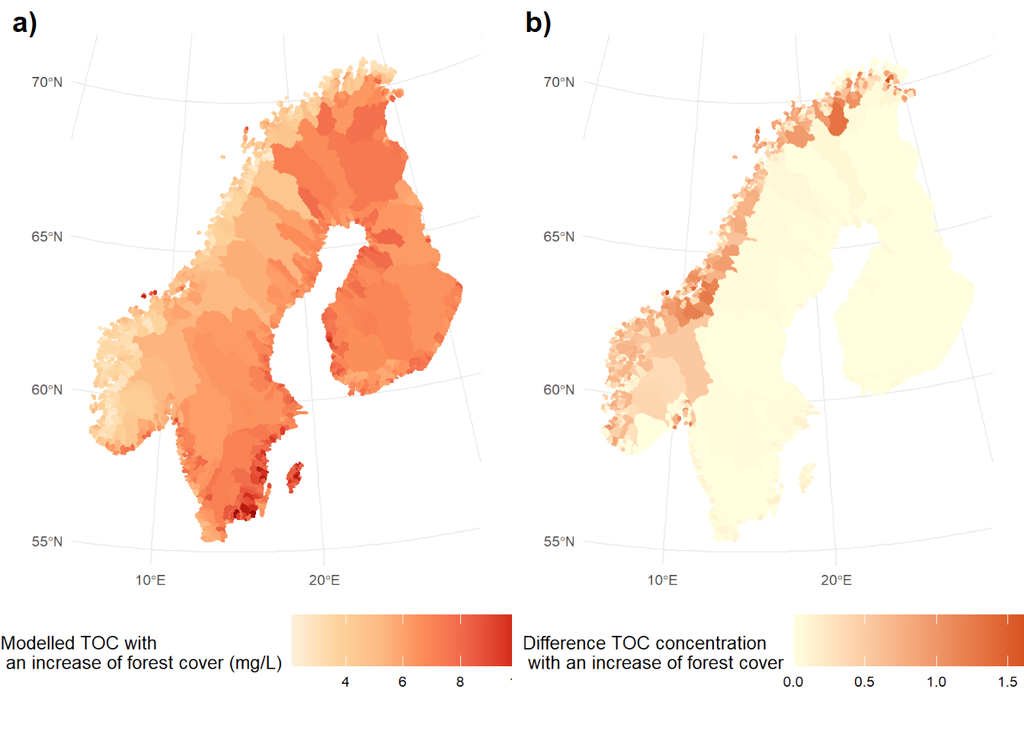

```r
listgrob <- list("WR/map.toc.forest.png","WR/map.diff.toc.forest.png") %>% lapply(readPNG) %>% lapply(rasterGrob)
plot_grid(plotlist = listgrob, ncol = 2, nrow = 1, labels = c("a)","b)"))
```

*Figure 9: Forecast of TOC concentration due to an increase of forest cover as a NbS to abate climate change. a) Modelled TOC with forest increase and b) difference with TOC concentration in 1995*

# 5 Conclusion

In this study, we compare the difference between two modeled values (TOC concentration fitted for 1995 and TOC concentration fitted for 2100). Therefore, we assume that the underestimation effect, for regions with high TOC concentration, is cancelled by the double-fit and that the difference in TOC concentration is a valid indicator for future changes. Moreover, the regions with high TOC concentration are also the regions with currently high forest cover. In these regions, the increase of forest cover is expected to be low, therefore the change of TOC concentration is also likely to be low.

In addition, an increase in forest cover will not immediately lead to an increase in TOC concentration, as soil formation and runoff processes are long-term processes that might not be captured in a space-for-time analysis. However, by comparing the predictions for 2100, i.e., after the full growth of the new forests), we assume that the “new” forest soils will have a pool of SOC comparable to the “old” forest soils.

As the previsions for planting new forest are much higher in Norway then in Sweden, the difference in TOC in the future is also highest in Norway. The forest increase is between 0 and 2% in Sweden and Finland, depending on the catchment, and the increase in TOC concentration remains under 0.5 mg/L in most of them. In Norway, the maximum increase is around 1.5 mg/L, in the North and in mid-Norge.

# References

Craig, Nicola, Stuart E. Jones, Brian C. Weidel, and Christopher T. Solomon. 2017. “Life history constraints explain negative relationship between fish productivity and dissolved organic carbon in lakes.” *Ecology and Evolution* 7 (16): 6201–9. https://doi.org/10.1002/ece3.3108.

Eikebrokk, B., R. D. Vogt, and H. Liltved. 2004. “NOM increase in Northern European source waters: Discussion of possible causes and impacts on coagulation/contact filtration processes.” In *Water Supply*, 4:47–54. 4. IWA Publishing. https://doi.org/10.2166/ws.2004.0060.

Energifakta Norge. n.d. “Electricity production.” Accessed January 25, 2022. https://energifaktanorge.no/en/norsk-energiforsyning/kraftproduksjon/.

Finstad, Anders G., Ingeborg P. Helland, Ola Ugedal, Trygve Hesthagen, and Dag O. Hessen. 2014. “Unimodal response of fish yield to dissolved organic carbon.” *Ecology Letters* 17 (1): 36–43. https://doi.org/10.1111/ele.12201.

Formas. 2012. “Swedish Research and Innovation Strategy for a Bio-based Economy.” Formas.

Haugland, H, E B Backer, E M Løbersli, O Selboe, H Gunnarsdottir, A Granhus, G Søgaard, et al. 2014. “Målrettet gjødsling av skog som klimatiltak – egnede arealer og miljøkriterier.” Miljødirektoratet.

Karlsson, Jan. 2007. “Different carbon support for respiration and secondary production in unproductive lakes.” *Oikos* 116 (10): 1691–96. https://doi.org/10.1111/j.0030-1299.2007.15825.x.

Karlsson, Jan, Pär Byström, Jenny Ask, Per Ask, Lennart Persson, and Mats Jansson. 2009. “Light limitation of nutrient-poor lake ecosystems.” *Nature* 460 (7254): 506–9. https://doi.org/10.1038/nature08179.

Lehtonen, Aleksi, and Raisa Mäkipää. 2021. “Impact assessment of climate actions in the land use sector-what can bring in the largest emission reductions?”

LUKE. n.d. “Land classes on forestry land (1000 ha) by inventory, region and land class.” Accessed March 10, 2022. https://statdb.luke.fi/PXWeb/pxweb/en/LUKE/LUKE__04 Metsa__06 Metsavarat/1.01_Metsatalousmaa.px/table/tableViewLayout2/.

Miljødirektoratet. 2013. “Planting av skog på nye arealer som klimatiltak. Egnede arealer og miljøkriterier.” *M26-2013.*, 152 s.

Ministry of Agriculture and Forestry. 2014. “Government Report on Forest Policy 2050.”

Näringsdepartementet. 2018. “Strategi för Sveriges nationella skogsprogram.”

Nordic Council of Ministers. 2021. “Policies for the promotion of BECCS in the Nordic Countries.” https://www.norden.org/en/publication/policies-promotion-beccs-nordic-countries.

Norsk Vann. 2019. “Vannkilder.” https://norskvann.no/vannforsyning-og-drikkevann/vannkilder/.

OECD. 2020. “Land cover in countries and regions.” https://stats.oecd.org/Index.aspx?DataSetCode=LAND_COVER.

Opdal, Anders Frugård, Christian Lindemann, and Dag L. Aksnes. 2019. “Centennial decline in North Sea water clarity causes strong delay in phytoplankton bloom timing.” *Global Change Biology* 25 (11): 3946–53. https://doi.org/10.1111/gcb.14810.

Region Skåne. 2020. “Remiss: SOU 2020:4. Vägen till en klimatpositiv framtid.” www.nj.se/offentligapublikationer https://www.regeringen.se/49c25e/contentassets/e5369df3a1374d3789addf21e7128539/region-skane.pdf.

Royal Swedish Academy of Agriculture and Forestry. 2015. “Forests and Forestry in Sweden.”

Statens Offentliga Utredningar. 2020. “Remissvar avseende SOU 2020:4, ”Vägen till en klimatpositiv framtid”.” www.nj.se/offentligapublikationer https://www.regeringen.se/49bc09/contentassets/e5369df3a1374d3789addf21e7128539/vattenfall-ab.pdf.

Sundnes, Frode, Marianne Karlsson, Froukje Maria Platjouw, Nicholas Clarke, Øyvind Kaste, and Salar Valinia. 2020. “Climate mitigation and intensified forest management in Norway: To what extent are surface waters safeguarded?” *Ambio* 49 (11): 1736–46. https://doi.org/10.1007/s13280-020-01357-1.

Swedish Forest Agency. 2012. “Forest and Forest Land.”

Tranvik, Lars J., John A. Downing, James B. Cotner, Steven A. Loiselle, Robert G. Striegl, Thomas J. Ballatore, Peter Dillon, et al. 2009. “Lakes and reservoirs as regulators of carbon cycling and climate.” *Limnology and Oceanography* 54 (6 PART 2): 2298–2314. https://doi.org/10.4319/lo.2009.54.6_part_2.2298.

UN Climate Change Conference UK. 2021. “Glasgow Leaders’ Declaration on Forests and Land Use - UN Climate Change Conference (COP26) at the SEC – Glasgow 2021.” https://ukcop26.org/glasgow-leaders-declaration-on-forests-and-land-use/.

Wit, Heleen A. de, Raoul Marie Couture, Leah Jackson-Blake, Martyn N. Futter, Salar Valinia, Kari Austnes, Jose Luis Guerrero, and Yan Lin. 2018. “Pipes or chimneys? For carbon cycling in small boreal lakes, precipitation matters most.” *Limnology And Oceanography Letters* 3 (3): 275–84. https://doi.org/10.1002/lol2.10077.

Yang, Hong, Tom Andersen, Peter Dörsch, Koji Tominaga, Jan Erik Thrane, and Dag O. Hessen. 2015. “Greenhouse gas metabolism in Nordic boreal lakes.” *Biogeochemistry* 126 (1-2): 211–25. https://doi.org/10.1007/s10533-015-0154-8.